# Simple BNPR Vignette

Michael Karcher

September 4, 2015

This vignette shows a simple and typical use of `phylodyn` and its main functions BNPR and BNPR_PS.

We start by loading the `phylodyn` package.

```r
set.seed(8675309)
library(phylodyn)
```

We need to set the true effective population size trajectory function. For this example, we choose a seasonal growth/collapse trajectory (already implemented in `phylodyn`).

```r
traj = logistic_traj
```

We set the end of the sampling interval and the number of samples we should expect.

```r
samp_end = 48
nsamps   = 500
```

We calculate the proportionality constant necessary to produce the correct expected number of samples. We then produce a set of samples by drawing from an inhomogeneous Poisson process with intensity proportional to the effective population size trajectory.

```r
Cprop      = nsamps/integrate(traj_beta, 0, samp_end, traj=traj, beta=1)$value
samp_times = pref_sample(traj, c=Cprop, lim=c(0,samp_end), beta=1)
```

We simulate a genealogy based on our sample using the coalescent.

```r
gene = coalsim(samp_times = samp_times, n_sampled = rep(1, length(samp_times)),
               traj = traj, lower_bound = 10)
```

We use BNPR and BNPR_PS to calculate approximate marginals (without and with a sampling model).

```r
res_BNPR    = BNPR(data = gene, lengthout = 100)
res_BNPR_PS = BNPR_PS(data = gene, lengthout = 100)
```

We plot the results.

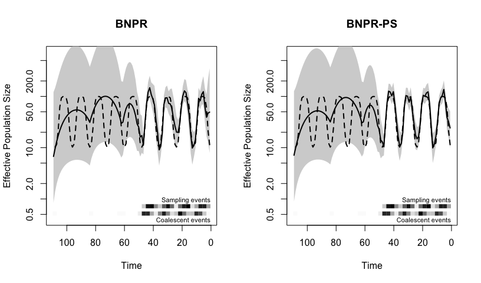

```r
par(mfrow=c(1,2))
plot_BNPR(res_BNPR, traj = traj, main="BNPR", ylim = c(1, 700))
plot_BNPR(res_BNPR_PS, traj = traj, main="BNPR-PS", ylim = c(1, 700))
```

## References

1. J. A. Palacios and V. N. Minin. Integrated nested Laplace approximation for Bayesian nonparametric phylodynamics. In *Proceedings of the Twenty-Eighth International Conference on Uncertainty in Artificial Intelligence*, pages 726–735, 2012.
2. M. S. Gill, P. Lemey, N. R. Faria, A. Rambaut, B. Shapiro, and M. A. Suchard. Improving Bayesian population dynamics inference: a coalescent-based model for multiple loci. *Molecular biology and evolution*, 30(3):713–724, 2013.